# cetm24_week11_Communitydetectioningraphs

### **Algorithm 1: Walktrap Community Detection**

The first method used is the **Walktrap algorithm**, which finds communities by running many short random walks. The idea is that walks are more likely to stay within a dense community than to cross to another.

- **Finding Communities**
  - `wc <- cluster_walktrap(karate)`: This command runs the Walktrap algorithm on the `karate` graph. The results, which include the community structure, are stored in the `wc` object. The output shows this process identified **5 distinct communities**.
- **Evaluating the result**
  - `modularity(wc)`: This calculates the **modularity** of the communities found by the Walktrap algorithm. Modularity is a score from -1 to 1 that measures how well a network is divided into communities. A higher score means denser connections within communities and sparser connections between them. The resulting modularity score is **0.353**.
  - `membership(wc)`: This command displays which community each node (person in the club) belongs to. For example, the output `[1] 1 1 2 1 5...` means the first node is in community 1, the second in community 1, the third in community 2, and so on.
- **Visualization**
  - `plot(wc, karate)`: This generates a plot of the karate club network, with nodes colored according to their community membership as determined by the Walktrap algorithm.
  - `dendPlot(wc, mode="hclust", rect = 5)`: This command creates a **dendrogram**, which is a tree diagram that shows how the algorithm hierarchically merged nodes and smaller groups into the final communities. The `rect = 5` argument draws rectangles around the five final clusters.

0.353221564760026

```
 [1] 1 1 2 1 5 5 5 1 2 2 5 1 1 2 3 3 5 1 3 1 3 1 3 4 4 4 3 4 2 3 2 2 3 3
```

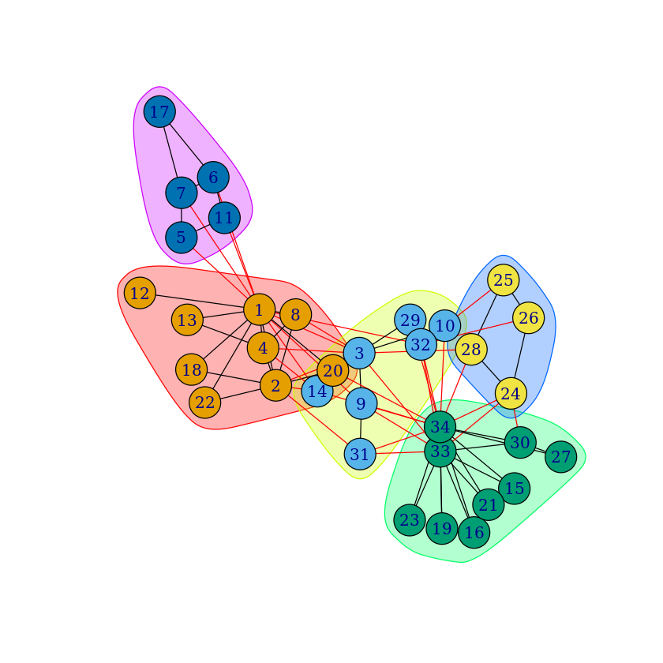

```r
# Load the igraph library
library(igraph)

# Create the Zachary karate club graph object
karate <- make_graph("Zachary")

#--- Walktrap Algorithm ---
# Find communities using the walktrap algorithm
wc <- cluster_walktrap(karate)

# Calculate the modularity of the detected communities
modularity(wc)

# View the community membership for each node
membership(wc)

# Plot the graph with communities highlighted
plot(wc, karate)
```

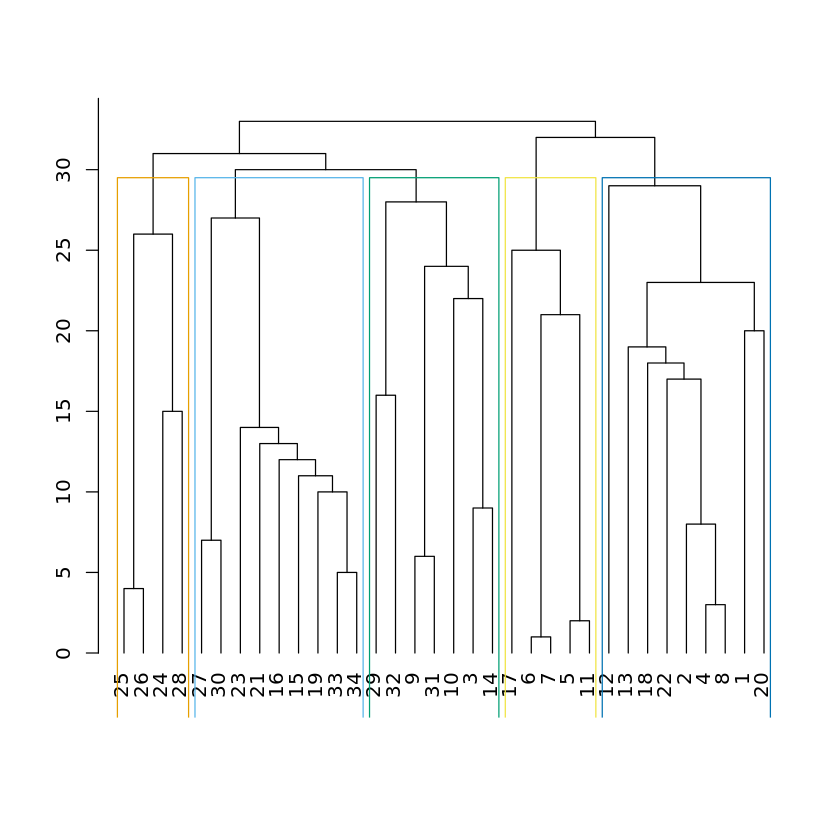

```r
# Plot the community dendrogram
dendPlot(wc, mode="hclust", rect = 5)
```

### **Algorithm 2: Louvain Community Detection**

Next, the document applies the **Louvain algorithm**, a popular method that optimizes modularity to find communities.

0.419789612097304

```
 [1] 1 1 1 1 2 2 2 1 3 3 2 1 1 1 3 3 2 1 3 1 3 1 3 4 4 4 3 4 4 3 3 4 3 3
```

```
Community sizes
 1  2  3  4
11  5 12  6
```

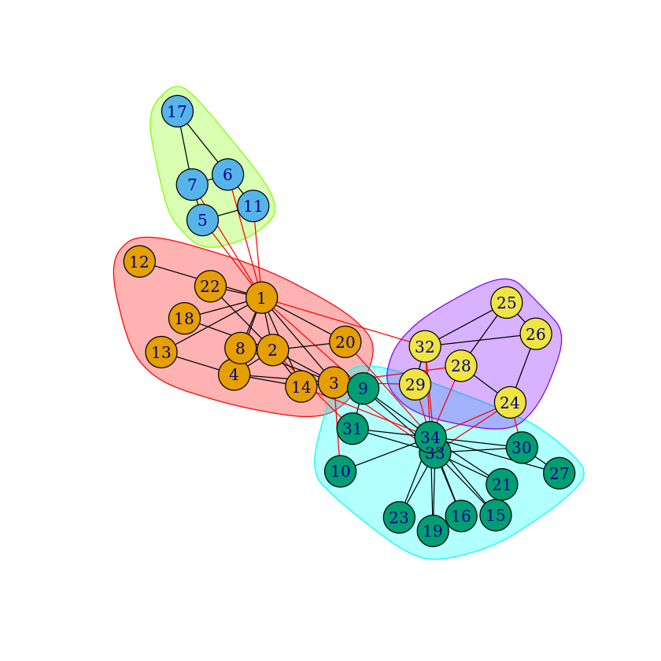

```r
#--- Louvain Algorithm ---
# Find communities using the Louvain algorithm
lc <- cluster_louvain(karate)

# Calculate the modularity
modularity(lc)

# View community membership
membership(lc)

# Plot the graph with communities
plot(lc, karate)

# Get the sizes of each community
sizes(lc)
```

[output not shown]

### **Algorithm 3: Link Community Detection**

Finally, the document demonstrates **link community detection**, which focuses on clustering the network's edges (links) rather than its nodes. This method is useful for identifying overlapping communities.

- **Preparation and Execution**
  - `library(linkcomm)`: This loads the `linkcomm` library needed for this specific algorithm.
  - `karate_el <- get.edgelist(karate)`: The `getLinkCommunities` function requires the network to be in the form of an **edge list** (a list of connected pairs). This command converts the `karate` graph object into that format.
  - `lc <- getLinkCommunities(karate_el, hcmethod = "single")`: This runs the link community detection algorithm on the edge list. The `hcmethod = "single"` specifies the hierarchical clustering method to be used ("single-linkage").
- **Visualization and Analysis**
  - `plot(lc, type = "summary")`: This plot provides a summary of the detected link communities, showing their size and how they relate to each other.
  - `cr <- getClusterRelatedness(...)`: This calculates how similar the detected communities are to each other, again using a specified clustering method (`ward.D`).
  - `cutDendrogramAt(...)`: This function takes the cluster relatedness dendrogram and "cuts" it at a specific height to form distinct meta-clusters.
    - Cutting at a height of `1.2` results in **2 communities**.

```
   Checking for loops and duplicate edges... 100.000%
   Calculating edge similarities for 78 edges... 100.00%
   Hierarchical clustering of edges...
   Calculating link densities... 100.00%
   Maximum partition density =  0.2847578
```

```
   Finishing up...4/4... 100.00%
   Plotting...
   Colouring dendrogram... 100%
```

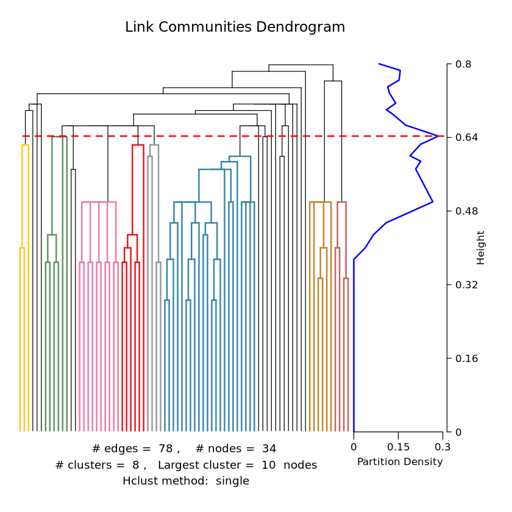

```r
# Load the linkcomm library
library(linkcomm)

# Convert the igraph object to an edge list, as required by the function
karate_el <- get.edgelist(karate)

# Get link communities [cite: 65]
lc <- getLinkCommunities(karate_el, hcmethod = "single")
```

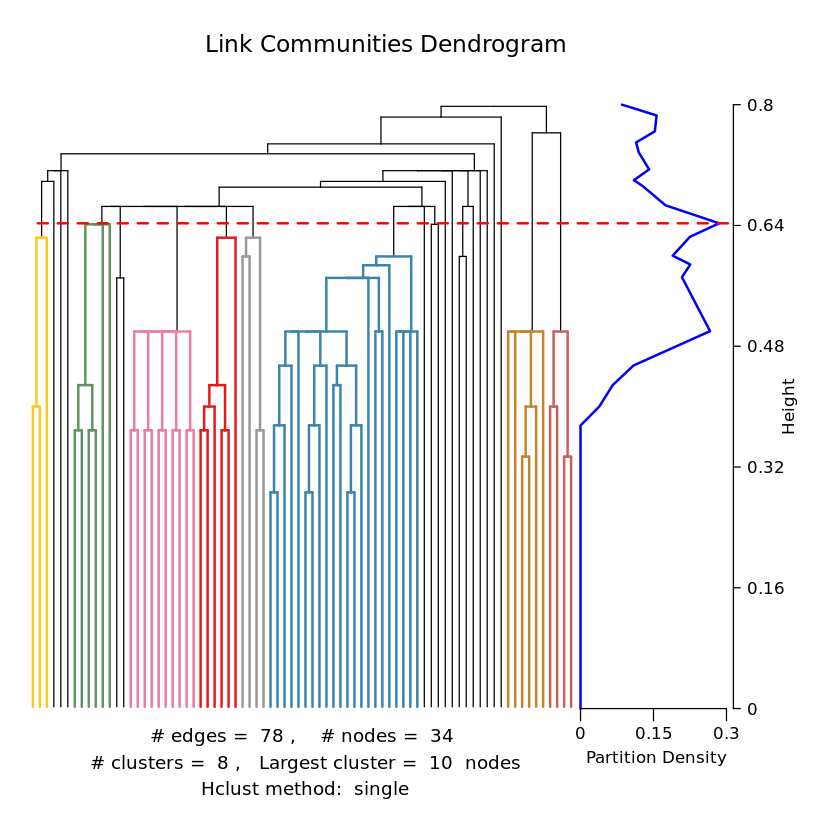

```r
# Plot a summary of the communities
plot(lc, type = "summary")
```

```r
# Function to merge small clusters like getLinkCommunities does
merge_small_clusters <- function(clusters, edge_list, min_size = 3) {
  cluster_sizes <- table(clusters)
  small_clusters <- as.numeric(names(cluster_sizes[cluster_sizes < min_size]))

  # Create new cluster assignments
  new_clusters <- clusters

  # Merge small clusters with their nearest larger cluster
  for(small_c in small_clusters) {
    edges_in_small <- which(clusters == small_c)
    if(length(edges_in_small) > 0) {
      # Find the most connected larger cluster
      # For simplicity, merge with the lowest numbered cluster
      new_clusters[edges_in_small] <- min(setdiff(unique(clusters), small_clusters))
    }
  }

  # Renumber clusters to be sequential
  unique_clusters <- unique(new_clusters)
  for(i in 1:length(unique_clusters)) {
    new_clusters[new_clusters == unique_clusters[i]] <- i
  }

  return(new_clusters)
}

# Apply post-processing to manual cut
raw_cut <- cutree(lc$hclust, h = 0.64)
processed_cut <- merge_small_clusters(raw_cut, karate_el)
print(paste("After merging small clusters:", length(unique(processed_cut)), "communities"))
```

```
[1] "After merging small clusters: 8 communities"
```

```
   Hierarchical clustering...
```

```
The "ward" method has been renamed to "ward.D"; note new "ward.D2"
```

```
   Plotting...
```

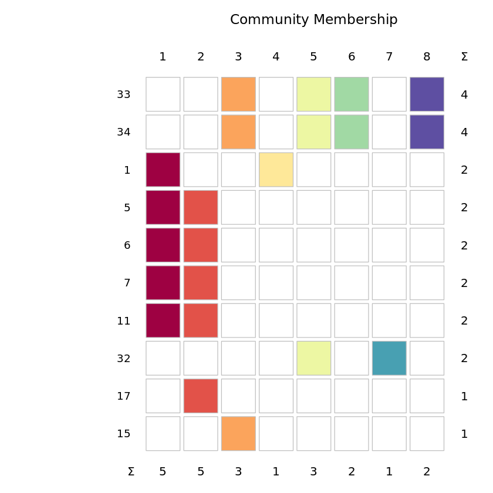

```
   Extracting clusters... 100.00%
   Colouring dendrogram... 100%
   Plotting...
```

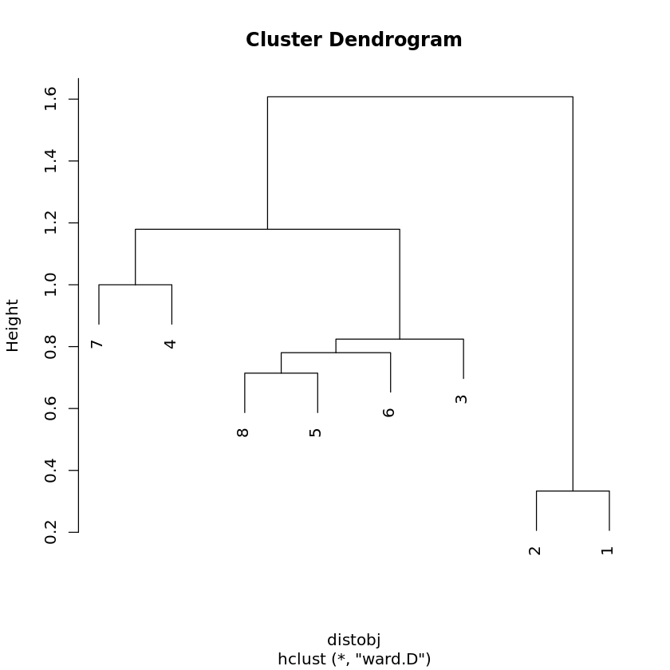

1. 1. 1

   2. 2

2. 1. 3

   2. 4

   3. 5

   4. 6

   5. 7

   6. 8

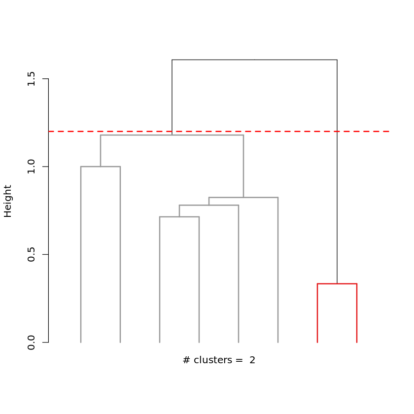

```r
# Plot the members of the communities
plot(lc, type = "members")

# Calculate cluster relatedness
cr <- getClusterRelatedness(lc, hcmethod = "ward")

# Cut the dendrogram at a specific height to define the number of communities
cutDendrogramAt(cr, cutat = 1.2)
```